# CITS4009 Project - Exploratory Data Analysis and Predictive Modeling

Binghan CHEN(23965953)

2024-10-13

[**Watch the Demonstration Video Here**](https://youtu.be/9IIQfb88t9U)

# **Introduction**

The objective of this project is to perform exploratory data analysis (EDA) and predictive modeling using the “Countries and Death Causes” dataset provided by the World Health Organisation (WHO). This dataset encompasses various health-related metrics for different countries over several years. Additionally, by integrating **GDP per Capita** data from the World Bank, we aim to examine the interplay between economic status and mortality rates. The primary goal is to uncover insights from the data and build predictive models to understand the factors influencing death rates. By analyzing these health and socioeconomic factors, we aim to identify key determinants of health outcomes and provide actionable recommendations for improving public health policies.

# **Section 1: Exploratory Study of the Data**

## **1.1. Data Overview**

### **1.1.1. Loading the Dataset**

```r
# Read the dataset
data <- read.csv("Countries_and_Death_Causes.csv", stringsAsFactors = FALSE)

# Display the first few rows of the dataset
head(data)
```

```
##        Entity Code Year Outdoor.air.pollution High.systolic.blood.pressure
## 1 Afghanistan  AFG 1990                  3169                        25633
## 2 Afghanistan  AFG 1991                  3222                        25872
## 3 Afghanistan  AFG 1992                  3395                        26309
## 4 Afghanistan  AFG 1993                  3623                        26961
## 5 Afghanistan  AFG 1994                  3788                        27658
## 6 Afghanistan  AFG 1995                  3869                        28090
##   Diet.high.in.sodium Diet.low.in.whole.grains Alochol.use Diet.low.in.fruits
## 1                1045                     7077         356               3185
## 2                1055                     7149         364               3248
## 3                1075                     7297         376               3351
## 4                1103                     7499         389               3480
## 5                1134                     7698         399               3610
## 6                1154                     7807         406               3703
##   Unsafe.water.source Secondhand.smoke Low.birth.weight Child.wasting
```

[output cut: 48 more lines]

The dataset includes 6,840 observations spanning from 1990 to 2019, covering various health and socio-economic indicators for different countries. Initial observations reveal a diverse range of metrics such as air pollution levels, blood pressure, dietary habits, and child health indicators, providing a comprehensive foundation for analysis.

### **1.1.2. Understanding the Structure of the Data**

```r
str(data)
```

```
## 'data.frame':    6840 obs. of  31 variables:
##  $ Entity                                  : chr  "Afghanistan" "Afghanistan" "Afghanistan" "Afghanistan" ...
##  $ Code                                    : chr  "AFG" "AFG" "AFG" "AFG" ...
##  $ Year                                    : int  1990 1991 1992 1993 1994 1995 1996 1997 1998 1999 ...
##  $ Outdoor.air.pollution                   : int  3169 3222 3395 3623 3788 3869 3943 4024 4040 4042 ...
##  $ High.systolic.blood.pressure            : int  25633 25872 26309 26961 27658 28090 28587 29021 29349 29712 ...
##  $ Diet.high.in.sodium                     : int  1045 1055 1075 1103 1134 1154 1178 1202 1222 1242 ...
##  $ Diet.low.in.whole.grains                : int  7077 7149 7297 7499 7698 7807 7943 8075 8173 8265 ...
##  $ Alochol.use                             : int  356 364 376 389 399 406 413 420 425 426 ...
##  $ Diet.low.in.fruits                      : int  3185 3248 3351 3480 3610 3703 3819 3938 4038 4127 ...
##  $ Unsafe.water.source                     : int  3702 4309 5356 7152 7192 8378 8487 9348 9788 9931 ...
##  $ Secondhand.smoke                        : int  4794 4921 5279 5734 6050 6167 6298 6425 6402 6323 ...
##  $ Low.birth.weight                        : int  16135 17924 21200 23795 24866 25534 25997 26246 25805 25080 ...
##  $ Child.wasting                           : int  19546 20334 22895 27002 29205 30943 31628 32736 32760 32271 ...
##  $ Unsafe.sex                              : int  351 361 378 395 410 422 435 448 458 469 ...
```

[output cut: 17 more lines]

The data frame consists of 31 variables, both categorical (e.g., `Entity`, `Code`) and numerical (e.g., `Outdoor.air.pollution`, `High.systolic.blood.pressure`). This structure allows for multifaceted analysis of health-related factors influencing mortality rates across countries and years.

### **1.1.3. Summary Statistics**

```r
summary(data)
```

```
##     Entity              Code                Year      Outdoor.air.pollution
##  Length:6840        Length:6840        Min.   :1990   Min.   :      0
##  Class :character   Class :character   1st Qu.:1997   1st Qu.:    434
##  Mode  :character   Mode  :character   Median :2004   Median :   2101
##                                        Mean   :2004   Mean   :  84582
##                                        3rd Qu.:2012   3rd Qu.:  11810
##                                        Max.   :2019   Max.   :4506193
##  High.systolic.blood.pressure Diet.high.in.sodium Diet.low.in.whole.grains
##  Min.   :       2             Min.   :      0.0   Min.   :      0.0
##  1st Qu.:    1828             1st Qu.:    137.0   1st Qu.:    273.8
##  Median :    8770             Median :    969.5   Median :   1444.0
##  Mean   :  224225             Mean   :  40497.2   Mean   :  38691.3
##  3rd Qu.:   40356             3rd Qu.:   5169.8   3rd Qu.:   6773.2
##  Max.   :10845595             Max.   :1885356.0   Max.   :1844836.0
##   Alochol.use        Diet.low.in.fruits  Unsafe.water.source Secondhand.smoke
##  Min.   :      0.0   Min.   :      0.0   Min.   :      0.0   Min.   :      1
##  1st Qu.:    263.8   1st Qu.:    144.0   1st Qu.:      7.0   1st Qu.:    209
##  Median :   1780.5   Median :    834.5   Median :    182.5   Median :    994
##  Mean   :  54848.6   Mean   :  23957.8   Mean   :  44086.4   Mean   :  30364
##  3rd Qu.:   8368.0   3rd Qu.:   3104.8   3rd Qu.:   5599.2   3rd Qu.:   4348
##  Max.   :2441973.0   Max.   :1046015.0   Max.   :2450944.0   Max.   :1304318
##  Low.birth.weight  Child.wasting       Unsafe.sex
##  Min.   :      0   Min.   :      0   Min.   :      0
##  1st Qu.:    123   1st Qu.:     26   1st Qu.:     97
##  Median :   1057   Median :    504   Median :    619
##  Mean   :  59126   Mean   :  49924   Mean   :  27646
##  3rd Qu.:  10903   3rd Qu.:   9765   3rd Qu.:   4492
##  Max.   :3033425   Max.   :3430422   Max.   :1664813
##  Diet.low.in.nuts.and.seeds Household.air.pollution.from.solid.fuels
##  Min.   :     0             Min.   :      0
##  1st Qu.:    27             1st Qu.:     32
##  Median :   252             Median :    821
##  Mean   : 12996             Mean   :  83641
##  3rd Qu.:  1998             3rd Qu.:  10870
##  Max.   :575139             Max.   :4358214
##  Diet.low.in.Vegetables Low.physical.activity    Smoking
##  Min.   :     0.0       Min.   :     0.0      Min.   :      1
##  1st Qu.:   109.0       1st Qu.:    92.0      1st Qu.:    894
##  Median :   590.5       Median :   521.5      Median :   4987
##  Mean   : 11982.5       Mean   : 16489.1      Mean   : 181958
```

[output cut: 15 more lines]

```
##  Max.   :1842275   Max.   :1200349                   Max.   :494492
##  Low.bone.mineral.density Vitamin.A.deficiency Child.stunting
##  Min.   :     0           Min.   :     0.0     Min.   :     0.0
##  1st Qu.:    43           1st Qu.:     0.0     1st Qu.:     1.0
##  Median :   277           Median :     2.0     Median :    41.5
##  Mean   :  8182           Mean   :  2471.6     Mean   : 11164.3
##  3rd Qu.:  1232           3rd Qu.:   230.2     3rd Qu.:  1563.2
##  Max.   :437884           Max.   :207555.0     Max.   :833449.0
##  Discontinued.breastfeeding Non.exclusive.breastfeeding Iron.deficiency
##  Min.   :    0.00           Min.   :     0.0            Min.   :    0
##  1st Qu.:    0.00           1st Qu.:     3.0            1st Qu.:    1
##  Median :    4.00           Median :    60.5            Median :   12
##  Mean   :  431.46           Mean   :  7171.9            Mean   : 1421
##  3rd Qu.:   71.25           3rd Qu.:  1315.5            3rd Qu.:  238
##  Max.   :33106.00           Max.   :505470.0            Max.   :73461
```

Summary statistics highlight significant variability in key health indicators:

- **Outdoor Air Pollution:** Ranges widely from 0 to over 4.5 million, indicating diverse environmental conditions.
- **High Systolic Blood Pressure:** Values vary from 2 to over 10 million, reflecting differing health profiles.
- **Dietary Factors:** Median sodium intake is 969.5, with substantial values in whole grains and fruits consumption.
- **Lifestyle Indicators:** Moderate alochol use (median ~1,780) and significant smoking rates (median ~4,987) suggest prevalent lifestyle risks.
- **Child Health Metrics:** Median values for child wasting and stunting indicate ongoing nutritional challenges.

## **1.2. Data Cleaning**

### **1.2.1. Checking for Missing Values**

```r
# Function to count missing values in each column
count_missing <- function(df) {
  sapply(df, function(col) sum(is.na(col)))
}

nacounts <- count_missing(data)
hasNA <- which(nacounts > 0)
nacounts[hasNA]
```

```
## named integer(0)
```

The analysis for missing values across all columns indicated that there are no missing entries in the dataset. Each variable is fully populated, ensuring data completeness and eliminating the need for imputation or the removal of incomplete records in subsequent analyses.

### **1.2.2. Handling Data Anomalies**

To ensure the accuracy and reliability of our analysis, it is essential to identify and address anomalies in the dataset. Outliers can skew results and lead to misleading interpretations. We focused on the following key variables for anomaly detection and removal:

- **Outdoor Air Pollution**
- **High Systolic Blood Pressure**
- **Diet High in Sodium**
- **Smoking**
- **High Body Mass Index**

**Detecting and Removing Outliers**

We utilized the Interquartile Range (IQR) method to detect outliers in the selected variables. The IQR method is effective in identifying extreme values that lie beyond 1.5 times the IQR above the third quartile or below the first quartile.

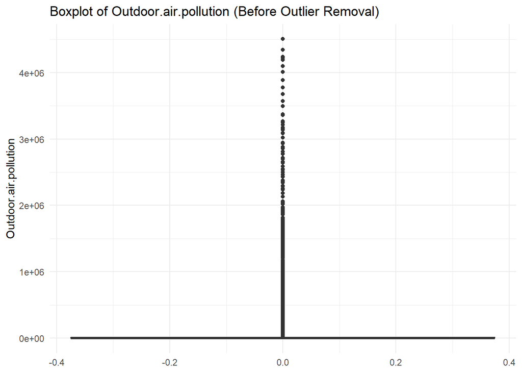

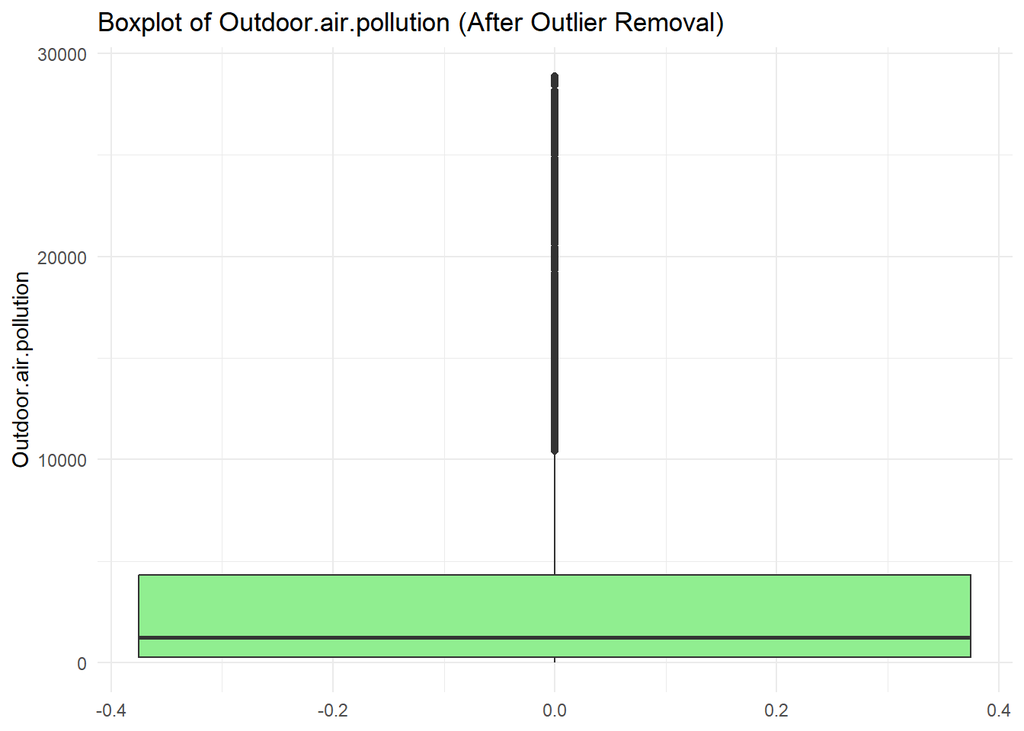

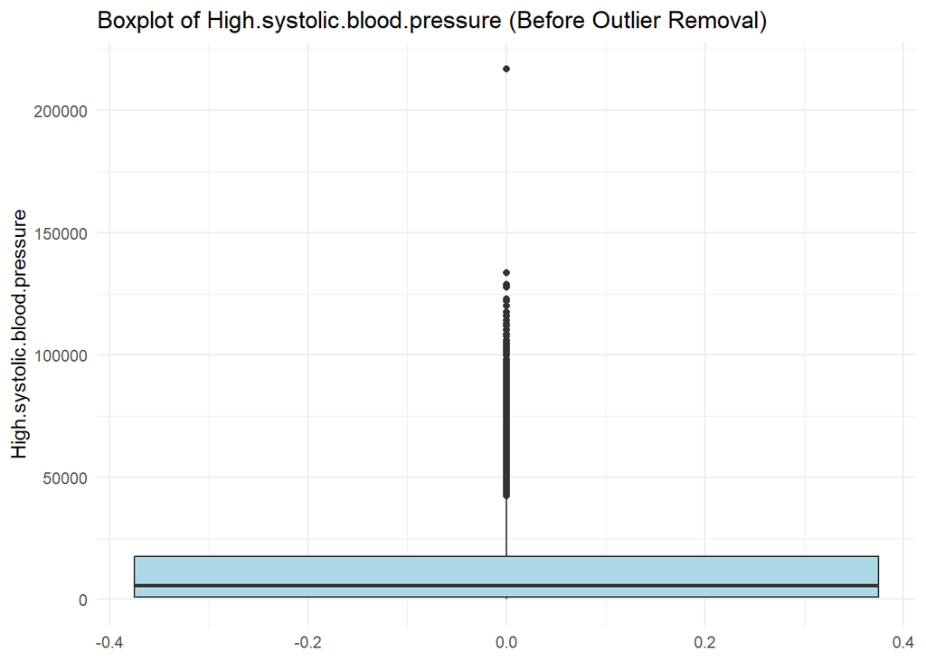

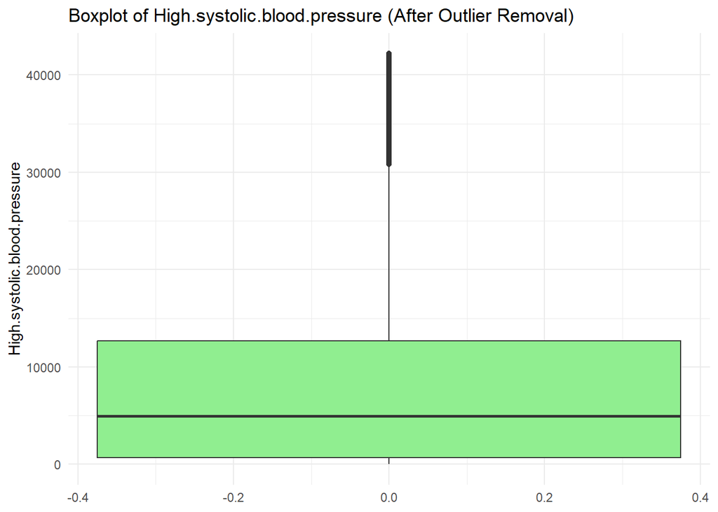

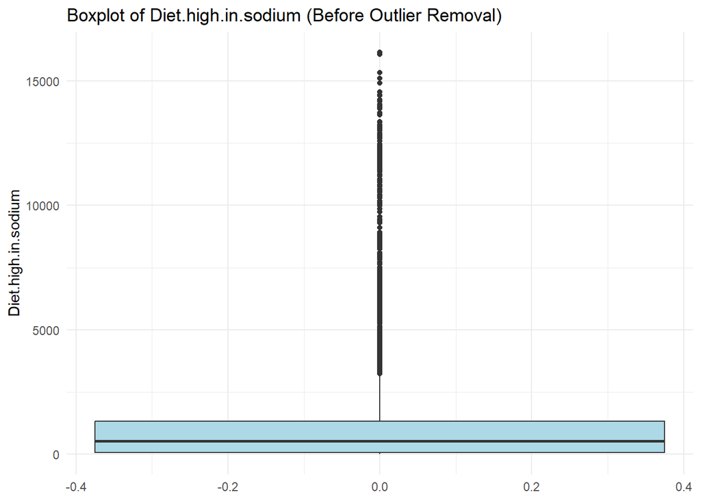

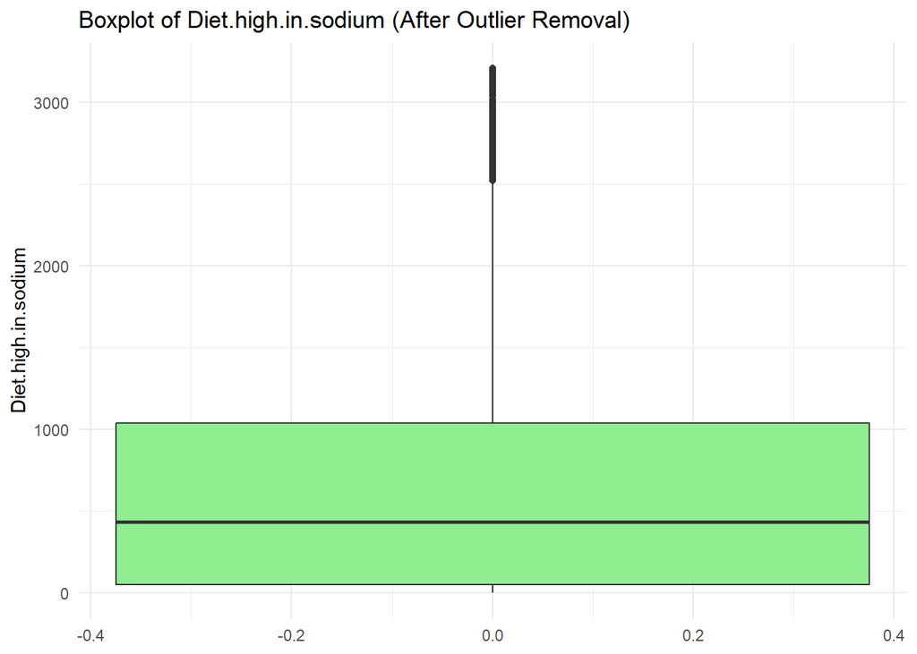

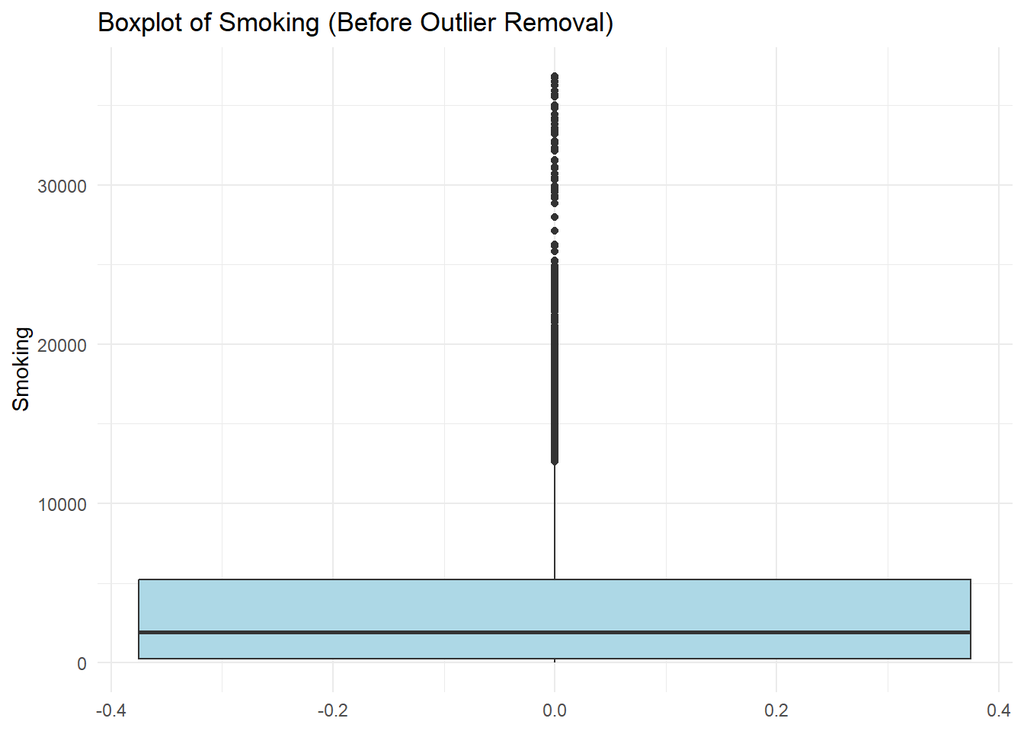

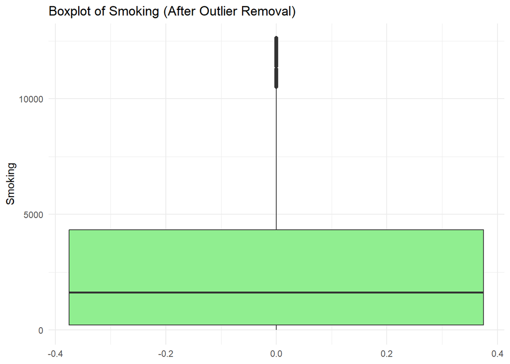

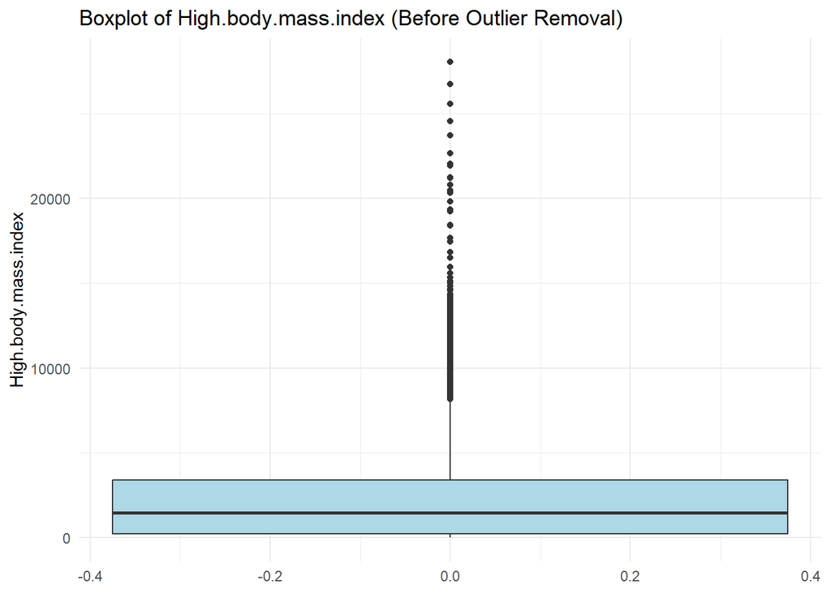

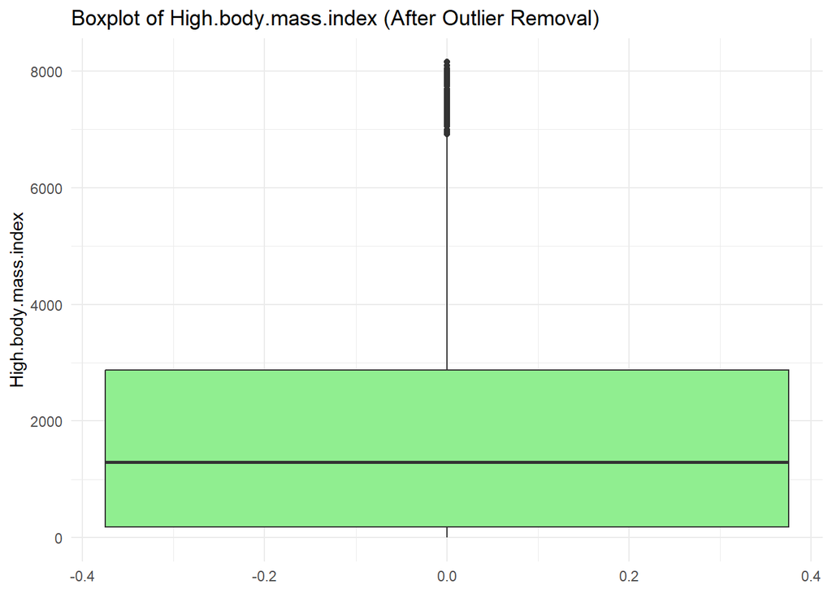

```r
# Create a clean copy of the dataset
data_clean <- data

# List of numerical columns to check for anomalies
key_numeric_cols <- c("Outdoor.air.pollution",
                      "High.systolic.blood.pressure",
                      "Diet.high.in.sodium",
                      "Smoking",
                      "High.body.mass.index")

# Function to remove outliers based on IQR for a given column
remove_outliers <- function(df, column) {
  Q1 <- quantile(df[[column]], 0.25, na.rm = TRUE)
  Q3 <- quantile(df[[column]], 0.75, na.rm = TRUE)
  IQR <- Q3 - Q1
  lower_bound <- Q1 - 1.5 * IQR
  upper_bound <- Q3 + 1.5 * IQR
  df_filtered <- df %>%
    filter(df[[column]] >= lower_bound & df[[column]] <= upper_bound)
  return(df_filtered)
}

# Iterate over each key column and remove outliers
for(col in key_numeric_cols){
  # Plot boxplot before removing outliers
  p_before <- ggplot(data_clean, aes_string(y = col)) +
    geom_boxplot(fill = "lightblue") +
    labs(title = paste("Boxplot of", col, "(Before Outlier Removal)"), y = col) +
    theme_minimal()

  print(p_before)

  # Remove outliers
  data_clean <- remove_outliers(data_clean, col)

  # Plot boxplot after removing outliers
  p_after <- ggplot(data_clean, aes_string(y = col)) +
    geom_boxplot(fill = "lightgreen") +
    labs(title = paste("Boxplot of", col, "(After Outlier Removal)"), y = col) +
    theme_minimal()

  print(p_after)
}
```

**Summary of Data Cleaning**

By addressing outliers in these key health-related variables, we have cleaned the dataset to minimize the risk of skewed analysis. This ensures that the exploratory study and predictive modeling reflect realistic trends and patterns in the global health data.

### **1.2.3. Final Cleaned Dataset**

After addressing missing values and removing significant outliers, the dataset is now cleaned and ready for further exploratory analysis and predictive modeling. The removal of extreme outliers has ensured that the distributions of key health-related variables such as air pollution, blood pressure, sodium consumption, smoking rates, and BMI are more representative of typical global trends. This clean dataset offers a reliable foundation for uncovering meaningful insights and building predictive models.

```r
# Display the first few rows of the cleaned dataset
head(data_clean)
```

```
##    Entity Code Year Outdoor.air.pollution High.systolic.blood.pressure
## 1 Albania  ALB 1990                  1017                         4280
## 2 Albania  ALB 1991                  1023                         4384
## 3 Albania  ALB 1992                   978                         4224
## 4 Albania  ALB 1993                   934                         4056
## 5 Albania  ALB 1994                   880                         3855
## 6 Albania  ALB 1995                   891                         4046
##   Diet.high.in.sodium Diet.low.in.whole.grains Alochol.use Diet.low.in.fruits
## 1                1561                      741         289                344
## 2                1593                      764         308                355
## 3                1530                      738         314                342
## 4                1466                      710         322                327
## 5                1385                      673         321                307
## 6                1446                      707         351                320
##   Unsafe.water.source Secondhand.smoke Low.birth.weight Child.wasting
```

[output cut: 48 more lines]

## **1.3. Visualisation**

### **1.3.1. Single Variable Visualisation**

We begin by exploring some key variables from the dataset to understand their distribution and general patterns.

- **Outdoor Air Pollution**

A histogram shows the distribution of pollution levels, and a boxplot identifies outliers. This variable is critical for understanding environmental factors contributing to health outcomes.

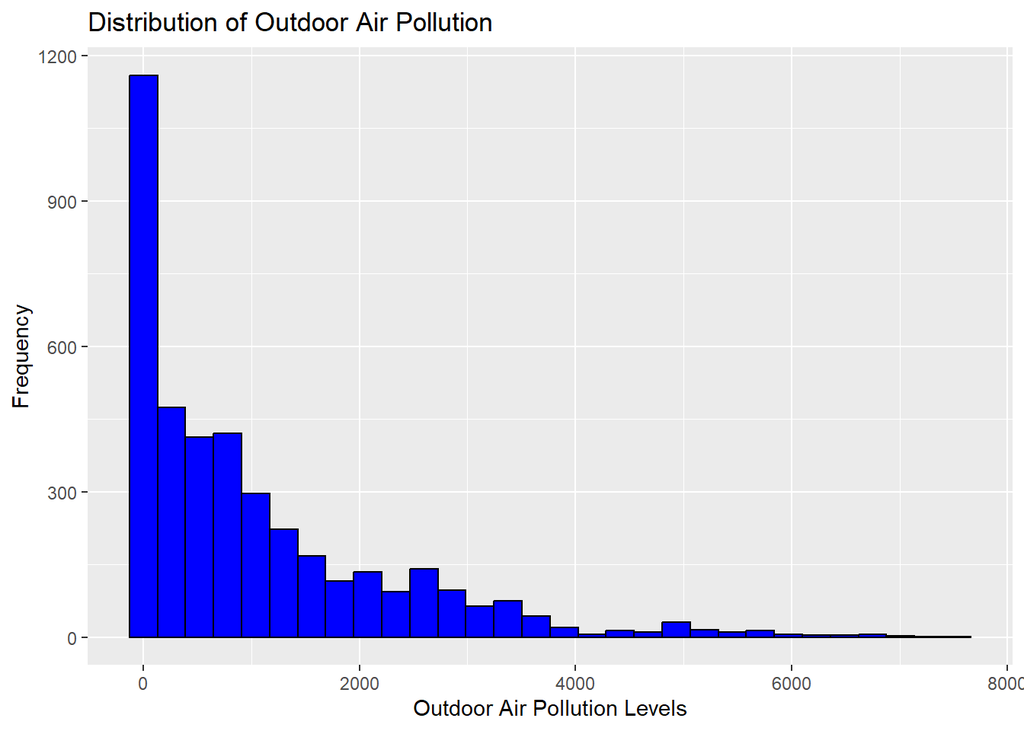

```r
# Histogram
ggplot(data_clean, aes(x = Outdoor.air.pollution)) +
  geom_histogram(fill = "blue", bins = 30, color = "black") +
  labs(title = "Distribution of Outdoor Air Pollution",
       x = "Outdoor Air Pollution Levels",
       y = "Frequency")
```

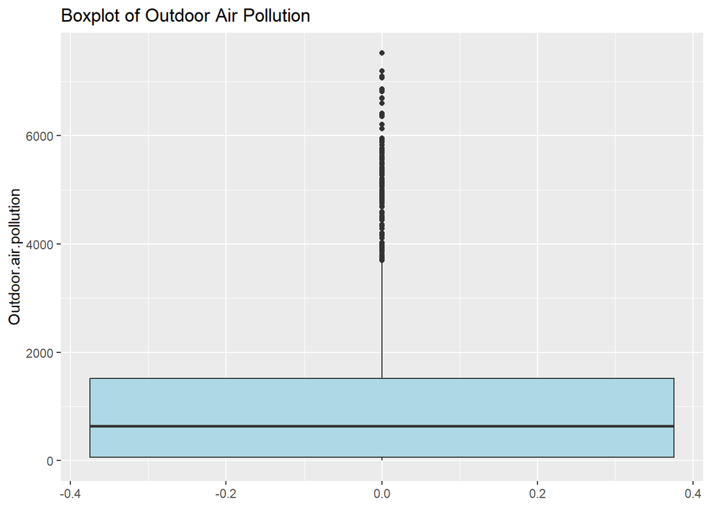

```r
# Boxplot
ggplot(data_clean, aes(y = Outdoor.air.pollution)) +
  geom_boxplot(fill = "lightblue") +
  labs(title = "Boxplot of Outdoor Air Pollution")
```

**Histogram:** The distribution of outdoor air pollution shows a heavy skew to the right, with most countries having lower levels of air pollution. Only a small number of cases exhibit significantly higher pollution levels.

**Boxplot:** The boxplot shows a significant number of outliers on the higher end. This indicates that while most countries have moderate pollution levels, there are a few extreme cases with very high pollution.

- **High Systolic Blood Pressure**

We visualize the distribution of systolic blood pressure levels to identify typical ranges and extreme values.

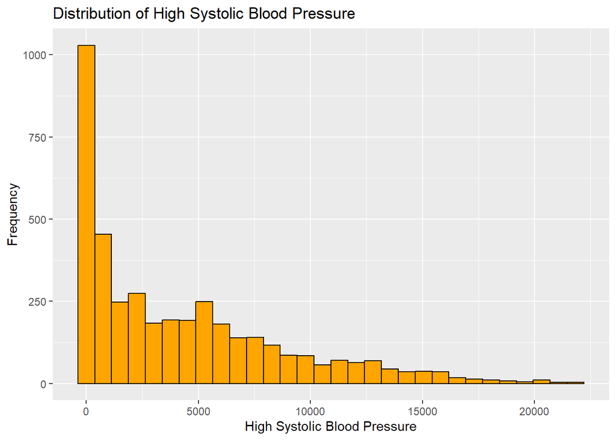

```r
# Histogram
ggplot(data_clean, aes(x = High.systolic.blood.pressure)) +
  geom_histogram(fill = "orange", bins = 30, color = "black") +
  labs(title = "Distribution of High Systolic Blood Pressure",
       x = "High Systolic Blood Pressure",
       y = "Frequency")
```

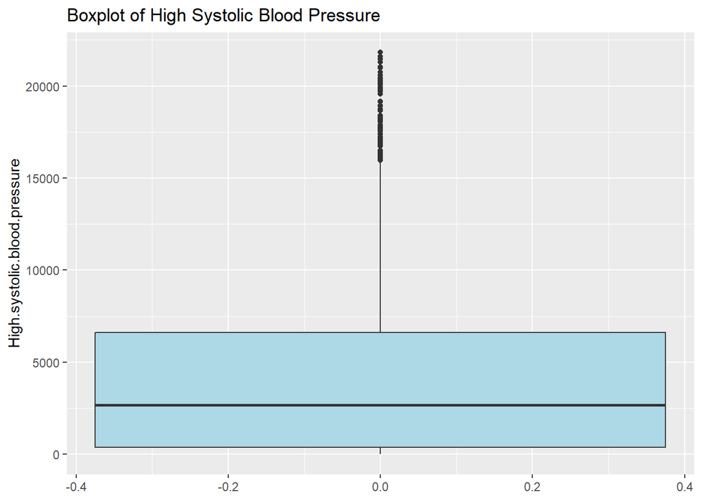

```r
# Boxplot
ggplot(data_clean, aes(y = High.systolic.blood.pressure)) +
  geom_boxplot(fill = "lightblue") +
  labs(title = "Boxplot of High Systolic Blood Pressure")
```

**Histogram:** This variable also has a right-skewed distribution, where the majority of countries have lower average systolic blood pressure levels. There is a noticeable long tail of higher blood pressure levels.

**Boxplot:** The presence of outliers in the boxplot indicates a small number of countries where the population’s systolic blood pressure levels are much higher than the global average.

- **Smoking**

Here, we examine the distribution of smoking rates across countries, focusing on global smoking patterns.

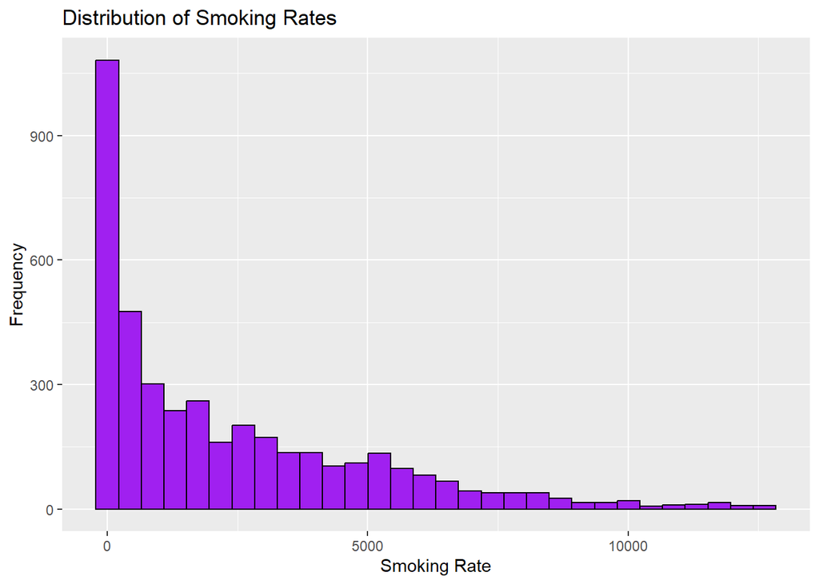

```r
# Histogram
ggplot(data_clean, aes(x = Smoking)) +
  geom_histogram(fill = "purple", bins = 30, color = "black") +
  labs(title = "Distribution of Smoking Rates",
       x = "Smoking Rate",
       y = "Frequency")
```

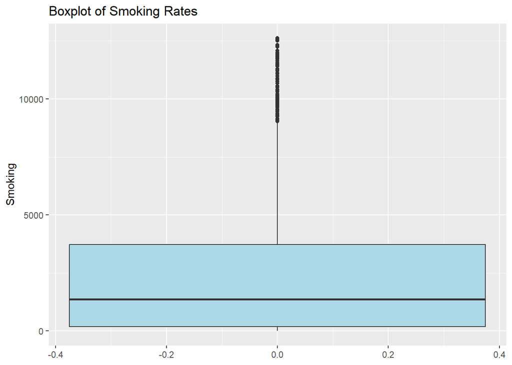

```r
# Boxplot
ggplot(data_clean, aes(y = Smoking)) +
  geom_boxplot(fill = "lightblue") +
  labs(title = "Boxplot of Smoking Rates")
```

**Histogram:** The smoking rates distribution is heavily skewed to the right, with the majority of countries having lower smoking rates. A few countries exhibit significantly higher rates, creating a long tail.

**Boxplot:** Similar to other variables, the boxplot shows several outliers indicating countries with extremely high smoking prevalence compared to the global trend.

- **Diet High in Sodium**

This visualization looks at sodium consumption patterns across countries, which is a major factor contributing to heart disease.

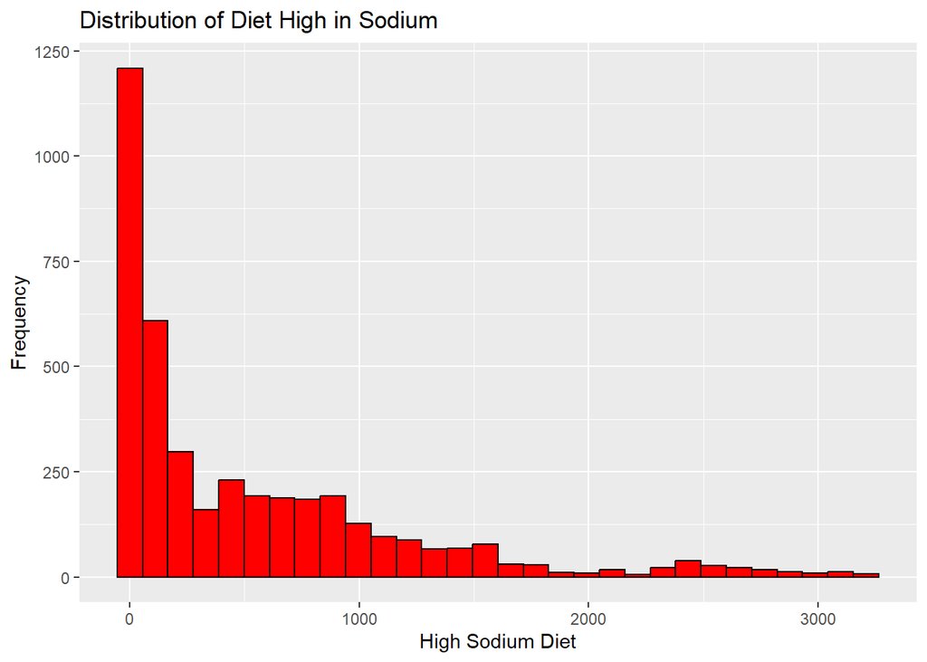

```r
# Histogram
ggplot(data_clean, aes(x = Diet.high.in.sodium)) +
  geom_histogram(fill = "red", bins = 30, color = "black") +
  labs(title = "Distribution of Diet High in Sodium",
       x = "High Sodium Diet",
       y = "Frequency")
```

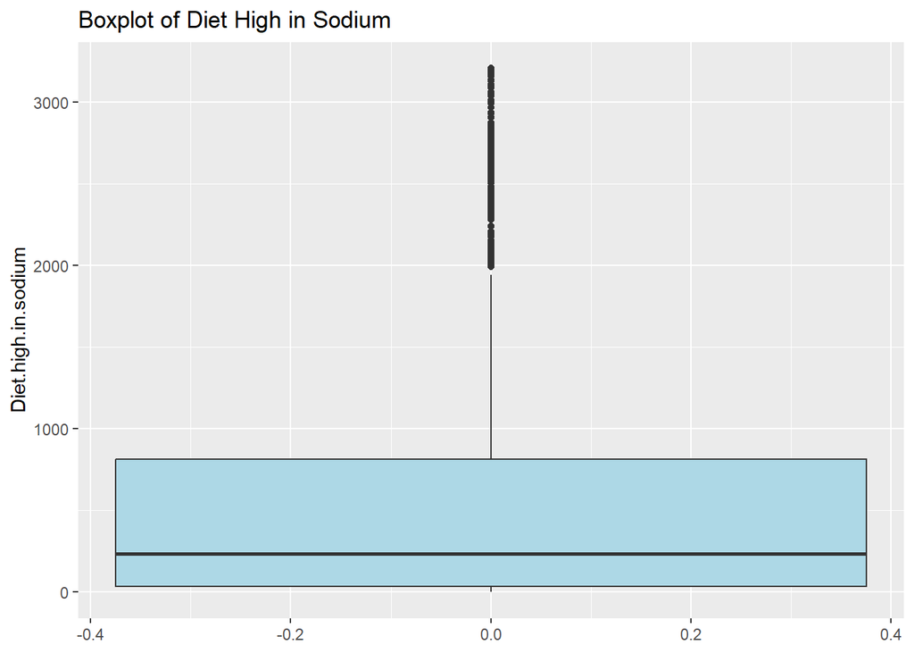

```r
# Boxplot
ggplot(data_clean, aes(y = Diet.high.in.sodium)) +
  geom_boxplot(fill = "lightblue") +
  labs(title = "Boxplot of Diet High in Sodium")
```

**Histogram:** The distribution for a high-sodium diet shows that most countries have relatively low sodium intake. There are fewer countries with higher sodium consumption.

**Boxplot:** The boxplot also displays outliers, suggesting that some countries consume a notably higher amount of sodium than the average.

### **1.3.2. Multiple Variable Visualisation**

We will explore relationships between different variables to identify any potential correlations, trends, or interesting patterns. A common way to visualize these relationships is by using scatter plots, correlation heatmaps, or pair plots.

- **Outdoor Air Pollution vs. High Systolic Blood Pressure**

This could explore the relationship between environmental pollution and blood pressure levels, which could reflect the impact of pollution on public health.

- **Smoking Rates vs. High Systolic Blood Pressure**

We could examine if there’s any visible trend between smoking rates and high blood pressure across different countries.

- **Diet High in Sodium vs. High Systolic Blood Pressure**

This explores the well-known relationship between sodium intake and high blood pressure, looking for trends in the data.

- **Smoking Rates vs. Diet High in Sodium**

Investigating whether countries with high smoking rates also have higher sodium consumption, which might reflect unhealthy lifestyle correlations.

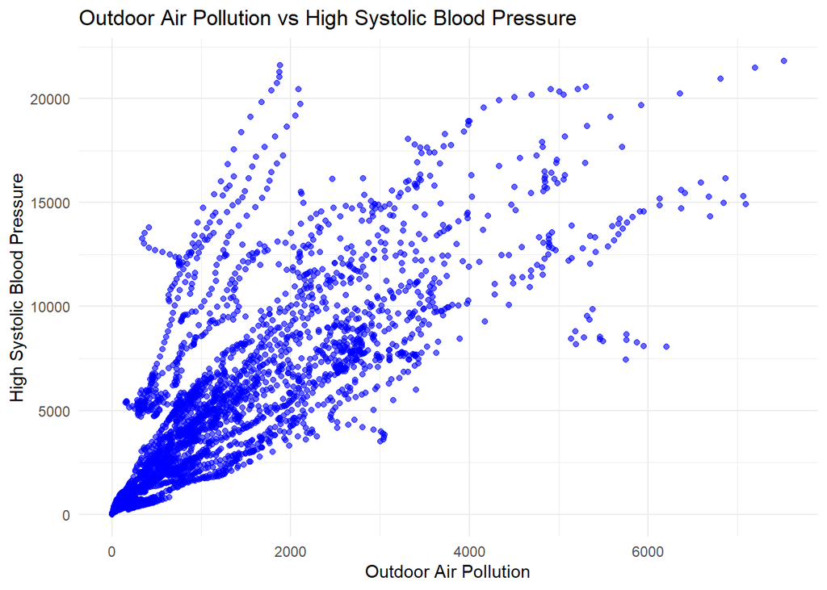

```r
# Multiple variable visualisation - Scatterplots

# 1. Outdoor Air Pollution vs. High Systolic Blood Pressure
ggplot(data_clean, aes(x = Outdoor.air.pollution, y = High.systolic.blood.pressure)) +
  geom_point(color = "blue", alpha = 0.6) +
  labs(title = "Outdoor Air Pollution vs High Systolic Blood Pressure",
       x = "Outdoor Air Pollution", y = "High Systolic Blood Pressure") +
  theme_minimal()
```

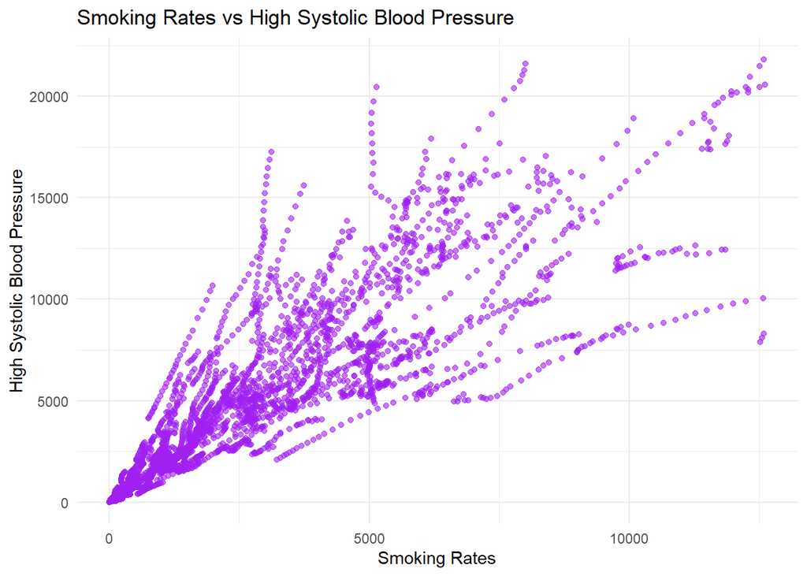

```r
# 2. Smoking Rates vs. High Systolic Blood Pressure
ggplot(data_clean, aes(x = Smoking, y = High.systolic.blood.pressure)) +
  geom_point(color = "purple", alpha = 0.6) +
  labs(title = "Smoking Rates vs High Systolic Blood Pressure",
       x = "Smoking Rates", y = "High Systolic Blood Pressure") +
  theme_minimal()
```

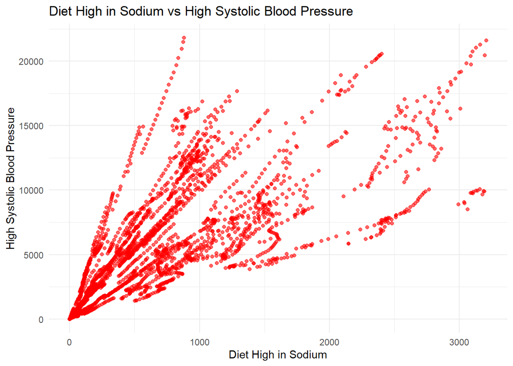

```r
# 3. Diet High in Sodium vs. High Systolic Blood Pressure
ggplot(data_clean, aes(x = Diet.high.in.sodium, y = High.systolic.blood.pressure)) +
  geom_point(color = "red", alpha = 0.6) +
  labs(title = "Diet High in Sodium vs High Systolic Blood Pressure",
       x = "Diet High in Sodium", y = "High Systolic Blood Pressure") +
  theme_minimal()
```

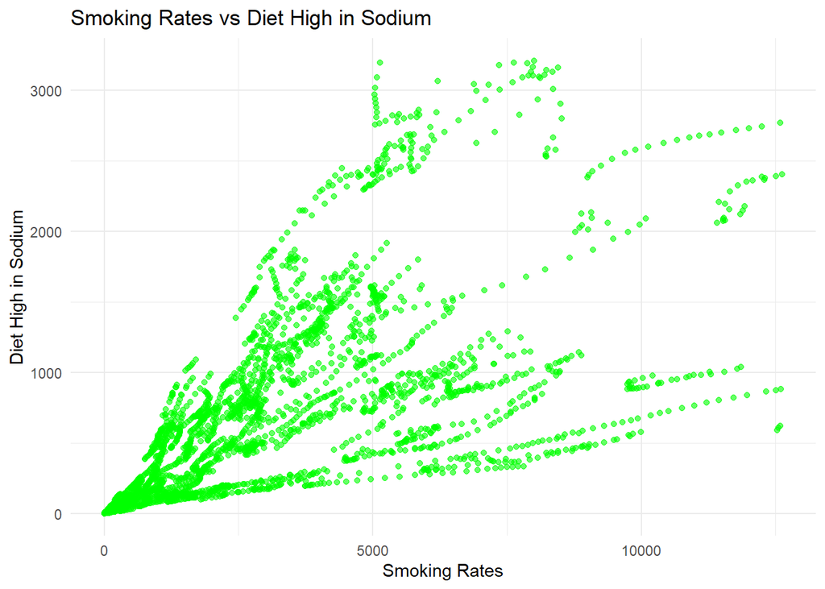

```r
# 4. Smoking Rates vs. Diet High in Sodium
ggplot(data_clean, aes(x = Smoking, y = Diet.high.in.sodium)) +
  geom_point(color = "green", alpha = 0.6) +
  labs(title = "Smoking Rates vs Diet High in Sodium",
       x = "Smoking Rates", y = "Diet High in Sodium") +
  theme_minimal()
```

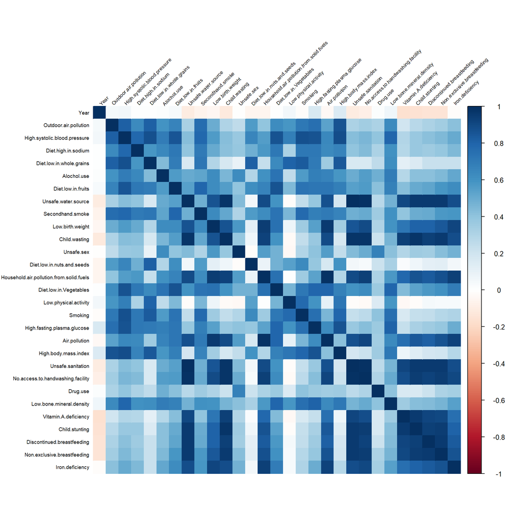

```r
# 5. Correlation heatmap (if multiple variables are being explored at once)
numeric_vars <- data_clean[, sapply(data_clean, is.numeric)]
corr_matrix <- cor(numeric_vars, use = "complete.obs")
corrplot(corr_matrix, method = "color", tl.cex = 0.6, number.cex = 0.7, tl.col = "black", tl.srt = 45)
```

**Interpretation of Results**:

- **Outdoor Air Pollution vs. High Systolic Blood Pressure**

The scatter plot demonstrates a positive correlation between outdoor air pollution and high systolic blood pressure. As pollution levels increase, so do systolic blood pressure levels. This suggests that environmental factors like air quality may play a role in blood pressure-related health outcomes across different regions.

- **Smoking Rates vs. High Systolic Blood Pressure**

There is also a positive relationship between smoking rates and systolic blood pressure. Higher smoking rates correlate with higher blood pressure levels, reinforcing the well-known link between smoking and cardiovascular health risks.

- **Diet High in Sodium vs. High Systolic Blood Pressure**

This scatter plot highlights a strong positive correlation between high sodium diet and systolic blood pressure. As sodium intake increases, systolic blood pressure also rises significantly. This observation aligns with existing health research that high sodium intake contributes to hypertension.

- **Smoking Rates vs. Diet High in Sodium**

Interestingly, the relationship between smoking rates and sodium intake is less pronounced but still suggests that higher smoking prevalence might coincide with higher sodium consumption. This could point to broader lifestyle or dietary patterns in certain regions.

- **Correlation Heatmap**

The heatmap provides an overview of the correlations between all variables in the dataset. Darker colors represent stronger positive correlations, while lighter colors indicate weaker or negative relationships. Notably, high systolic blood pressure shows strong correlations with several lifestyle factors, including smoking and diet. Similarly, outdoor air pollution also correlates with multiple health outcomes.

### **1.3.3. Time Series Visualisation**

We aim to explore how key health metrics, such as outdoor air pollution, smoking rates, and high systolic blood pressure, have changed over time. Time series visualizations will allow us to identify trends, fluctuations, and patterns across different years.

- **Time Series of Outdoor Air Pollution Over the Years**

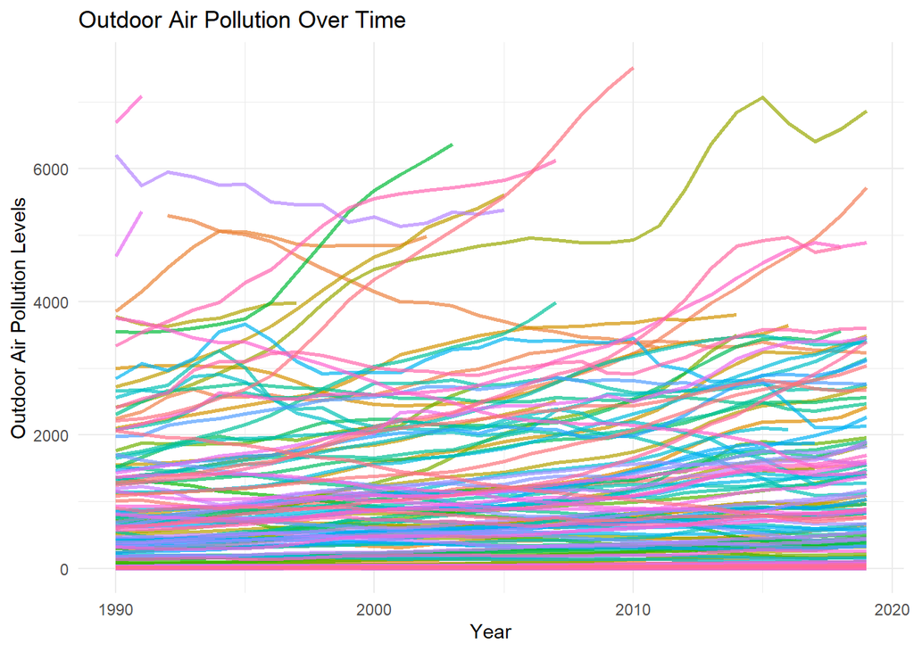

```r
ggplot(data_clean, aes(x = Year, y = Outdoor.air.pollution, color = Entity)) +
  geom_line(linewidth = 1, alpha = 0.7) +
  theme_minimal() +
  labs(title = "Outdoor Air Pollution Over Time",
       x = "Year",
       y = "Outdoor Air Pollution Levels") +
  theme(legend.position = "none")
```

The time series plot for Outdoor Air Pollution shows varied trends among different countries. Some countries experienced a notable increase in outdoor air pollution over time, especially after 2000, while others remained relatively stable or even declined slightly. The visual differences across countries highlight the diverse environmental situations worldwide. This trend could suggest that some nations are more susceptible to rising air pollution due to factors like industrialization or lack of pollution control measures.

- **Time Series of High Systolic Blood Pressure Over the Years**

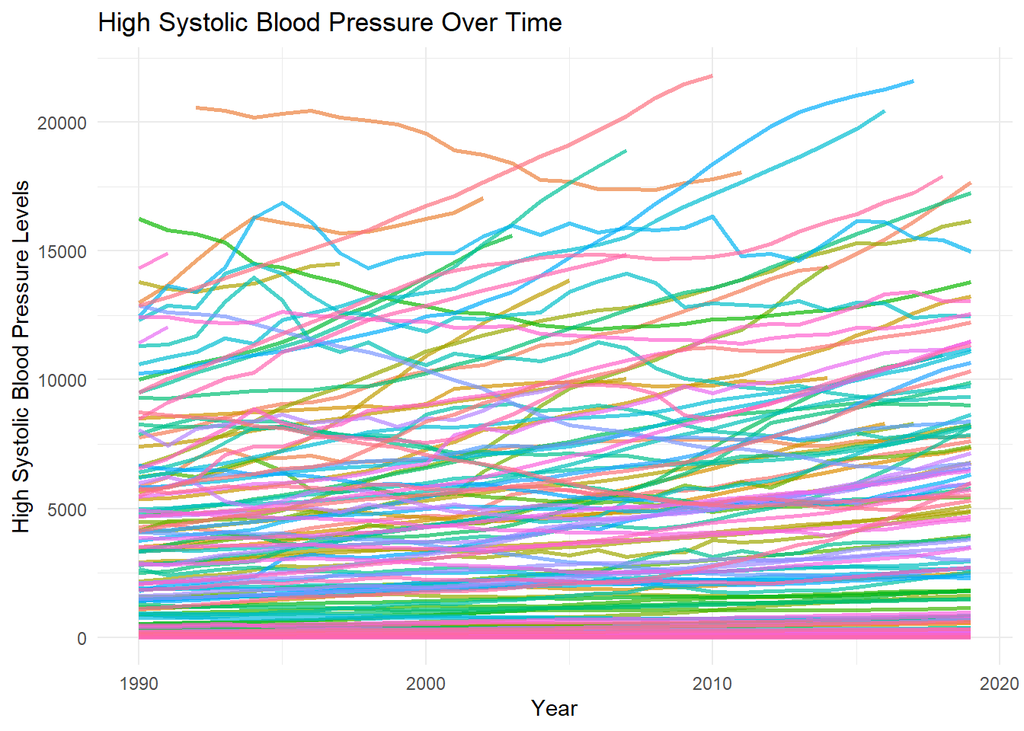

```r
# Time Series for High Systolic Blood Pressure
ggplot(data_clean, aes(x = Year, y = High.systolic.blood.pressure, color = Entity)) +
  geom_line(size = 1, alpha = 0.7) +
  theme_minimal() +
  labs(title = "High Systolic Blood Pressure Over Time",
       x = "Year",
       y = "High Systolic Blood Pressure Levels") +
  theme(legend.position = "none")
```

For High Systolic Blood Pressure, the time series visualization reveals that, while most countries exhibit a consistent increase in blood pressure levels, there are fluctuations for certain countries. This increasing trend aligns with global health concerns regarding lifestyle-related diseases such as hypertension, which could be influenced by factors such as diet and physical inactivity. A few countries also show relatively higher levels of systolic blood pressure throughout the observed years.

- **Time Series of Smoking Rates Over the Years**

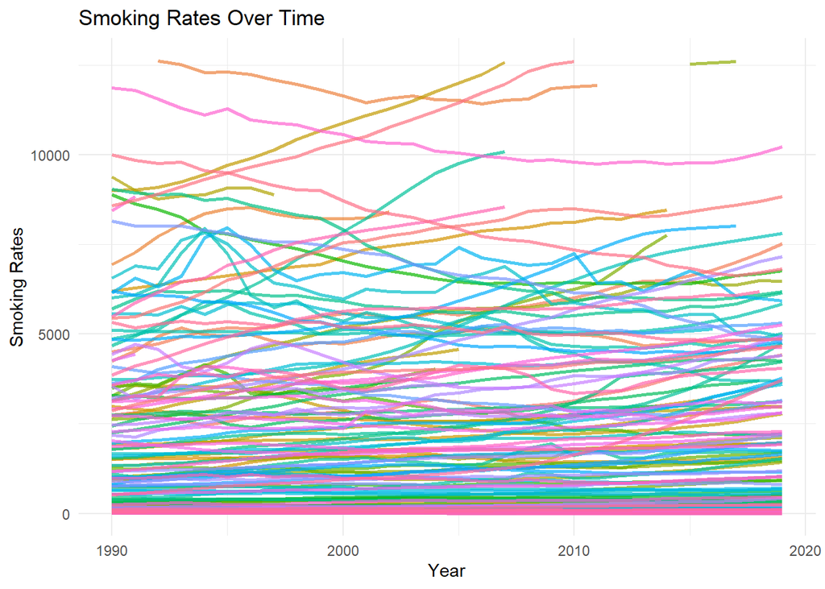

```r
# Time Series for Smoking Rates
ggplot(data_clean, aes(x = Year, y = Smoking, color = Entity)) +
  geom_line(size = 1, alpha = 0.7) +
  theme_minimal() +
  labs(title = "Smoking Rates Over Time",
       x = "Year",
       y = "Smoking Rates") +
  theme(legend.position = "none")
```

The Smoking Rates Over Time plot shows a range of trends, with some countries witnessing steady increases in smoking rates, while others experience fluctuations or even a decline over time. The wide variation in smoking behaviors across countries could be due to factors such as public health initiatives, taxation on tobacco, or cultural practices. Despite some regions reducing smoking rates, many countries still show significantly high levels, which can have a direct impact on health-related issues, including high blood pressure and cardiovascular diseases.

# **Section 2: Predictive Modeling**

## **2.1. Problem Definition**

For this project, we aim to predict the **death rate** (high/low) for each country based on various health, socioeconomic, and environmental factors. The death rate serves as the response variable, which we will classify into two categories: **high** and **low** death rates. This binary classification will help to identify patterns and key factors contributing to death rates in different countries.

## **2.2. Data Preparation**

### **2.2.1. Response Variable**

We focus on creating a suitable response variable for the classification task. Given that the provided dataset (`Countries_and_Death_Causes`) does not directly contain death rates, we utilize additional data from the World Bank, specifically **total population** and **GDP per capita**. We aim to create a binary classification problem where countries are categorized based on mortality rates.

**a. Merging Datasets**:

We merge the `Countries_and_Death_Causes` dataset with the World Bank datasets, `data_population` (total population) and `data_GDP_per_Capita` (GDP per capita), by aligning the **country codes** and **years** in each dataset. This merged dataset will allow us to analyze health factors in relation to population size and economic conditions.

```r
# Load Population and GDP per Capita Data
population_df <- read_csv("Population_Data.csv")
gdp_df <- read_csv("GDP_per_Capita_Data.csv")

# Define a function to pivot data from wide to long
melt_data <- function(df, value_name) {
  df_long <- df %>%
    pivot_longer(
      cols = matches("^\\d{4}$"), # Select columns that are exactly four digits (e.g., 1960)
      names_to = "Year",
      values_to = value_name
    ) %>%
    mutate(
      Year = as.integer(Year)
    )
  return(df_long)
}

# Melt Population and GDP Data
population_long <- melt_data(population_df, "Population") %>%
  select(-'Indicator Name', -'Indicator Code') %>%
  drop_na(Population) %>%
  mutate(Population = as.numeric(Population))

gdp_long <- melt_data(gdp_df, "GDP_per_Capita") %>%
  select(-'Indicator Name', -'Indicator Code') %>%
  drop_na(GDP_per_Capita) %>%
  mutate(GDP_per_Capita = as.numeric(GDP_per_Capita))

# Ensure Year is integer in data_clean
data_clean <- data_clean %>%
  mutate(Year = as.integer(Year))

# Merge data_clean with Population Data
merged_df <- data_clean %>%
  left_join(population_long, by = c("Code" = "Country Code", "Year" = "Year"))

# Merge with GDP per Capita Data
merged_df <- merged_df %>%
  left_join(gdp_long, by = c("Code" = "Country Code", "Year" = "Year"))

# Remove rows with missing Population or GDP_per_Capita after merge
merged_df <- merged_df %>%
  drop_na(Population, GDP_per_Capita)

# Retain only rows where Country.Code has exactly three letters
merged_df <- merged_df %>%
  filter(str_length(Code) == 3)

# Identify valid Country Codes from population_long and gdp_long
valid_country_codes <- intersect(population_long$'Country Code', gdp_long$'Country Code')

# Filter merged_df to include only valid Country Codes
merged_df <- merged_df %>%
  filter(Code %in% valid_country_codes)

# Check for duplicate rows based on Country.Code and Year
duplicated_rows <- merged_df %>%
  group_by(Code, Year) %>%
  filter(n() > 1)

# Handle Duplicates
if(nrow(duplicated_rows) > 0){
  print("Duplicated Rows Found:")
  print(duplicated_rows)

  # Optionally, remove duplicates by keeping the first occurrence
  merged_df <- merged_df %>%
    distinct(Code, Year, .keep_all = TRUE)

  print("Duplicates have been removed by keeping the first occurrence.")
} else {
  print("No duplicate rows based on Country.Code and Year.")
}
```

```
## [1] "No duplicate rows based on Country.Code and Year."
```

```r
# Verify specific entries (optional)
# Example: Check data for Albania in 1990
albania_1990 <- merged_df %>%
  filter(Code == "ALB", Year == 1990)

print(albania_1990)
```

```
##    Entity Code Year Outdoor.air.pollution High.systolic.blood.pressure
## 1 Albania  ALB 1990                  1017                         4280
##   Diet.high.in.sodium Diet.low.in.whole.grains Alochol.use Diet.low.in.fruits
## 1                1561                      741         289                344
##   Unsafe.water.source Secondhand.smoke Low.birth.weight Child.wasting
## 1                  53              902              731           840
##   Unsafe.sex Diet.low.in.nuts.and.seeds
## 1         47                        309
##   Household.air.pollution.from.solid.fuels Diet.low.in.Vegetables
## 1                                     1978                    186
##   Low.physical.activity Smoking High.fasting.plasma.glucose Air.pollution
## 1                   117    2752                         868          2965
##   High.body.mass.index Unsafe.sanitation No.access.to.handwashing.facility
## 1                 1417                31                                67
##   Drug.use Low.bone.mineral.density Vitamin.A.deficiency Child.stunting
## 1       64                       44                   29            390
##   Discontinued.breastfeeding Non.exclusive.breastfeeding Iron.deficiency
## 1                          2                         171               4
##   Country Name.x Population Country Name.y GDP_per_Capita
## 1        Albania    3286542        Albania       617.2304
```

```r
# Confirmation message
print("Datasets merged successfully!")
```

```
## [1] "Datasets merged successfully!"
```

**b. Mortality Proxy Calculation**:

To predict the death rate for each country, we construct a **Mortality Proxy** that aggregates various health-related and environmental risk factors. This proxy serves as an estimated measure of mortality risk, combining multiple indicators into a single, comprehensive metric. By normalizing the sum of these factors by the country’s total population, we ensure that the proxy accounts for population size, facilitating meaningful comparisons across countries.

The formula for the Mortality Proxy is as follows:

$$\small{
\text{Mortality Proxy} = \frac{\text{Outdoor Air Pollution} + \text{High
Systolic Blood Pressure} + \text{Diet High in Sodium} +
\dots}{\text{Total Population}}
}$$

This approach assumes that higher values in the aggregated health and environmental factors correspond to increased mortality risks. Dividing by the population yields a per capita measure, allowing us to compare mortality risks between countries with different population sizes.

```r
# Define the health-related variables to include in the Mortality Proxy
health_vars <- c(
  "Outdoor.air.pollution",
  "High.systolic.blood.pressure",
  "Diet.high.in.sodium",
  "Alochol.use",
  "Diet.low.in.whole.grains",
  "Diet.low.in.fruits",
  "Unsafe.water.source",
  "Secondhand.smoke",
  "Low.birth.weight",
  "Child.wasting",
  "Unsafe.sex",
  "Diet.low.in.nuts.and.seeds",
  "Household.air.pollution.from.solid.fuels",
  "Diet.low.in.Vegetables",
  "Low.physical.activity",
  "Smoking",
  "High.fasting.plasma.glucose",
  "Air.pollution",
  "High.body.mass.index",
  "Unsafe.sanitation",
  "No.access.to.handwashing.facility",
  "Drug.use",
  "Low.bone.mineral.density",
  "Vitamin.A.deficiency",
  "Child.stunting",
  "Discontinued.breastfeeding",
  "Non.exclusive.breastfeeding",
  "Iron.deficiency"
)

# Check if all health-related variables are present in merged_df
missing_vars <- setdiff(health_vars, colnames(merged_df))
if(length(missing_vars) > 0){
  stop("The following health-related variables are missing in merged_df: ", paste(missing_vars, collapse = ", "))
}

# Calculate the Mortality Proxy
merged_df <- merged_df %>%
  mutate(
    Mortality_Proxy = rowSums(select(., all_of(health_vars)), na.rm = TRUE) / Population
  )

# Display the first few rows to verify the calculation
head(merged_df %>% select(Code, Year, Mortality_Proxy))
```

```
##   Code Year Mortality_Proxy
## 1  ALB 1990     0.006754516
## 2  ALB 1991     0.006928820
## 3  ALB 1992     0.006729516
## 4  ALB 1993     0.006499577
## 5  ALB 1994     0.006193227
## 6  ALB 1995     0.006344533
```

**c. Defining Binary Classes**:

With the Mortality Proxy calculated, we categorize each country-year observation into two classes: **High Mortality Rate** and **Low Mortality Rate**. This binary classification simplifies the predictive modeling process.

- **High Mortality Rate**: Countries with Mortality Proxy values **above or equal to** the 75th percentile of the distribution.
- **Low Mortality Rate**: Countries with Mortality Proxy values **below** the 75th percentile of the distribution.

This approach ensures that the top 25% of observations are identified as high-risk, providing a balanced foundation for classification algorithms.

```r
# Calculate the 75th percentile threshold for Mortality Proxy
threshold <- quantile(merged_df$Mortality_Proxy, 0.75, na.rm = TRUE)

# Define binary classes based on the threshold
merged_df <- merged_df %>%
  mutate(
    Mortality_Class = if_else(
      Mortality_Proxy >= threshold,
      "High Mortality Rate",
      "Low Mortality Rate"
    )
  )

# Verify the distribution of the binary classes
class_distribution <- table(merged_df$Mortality_Class)
print(class_distribution)
```

```
##
## High Mortality Rate  Low Mortality Rate
##                 947                2838
```

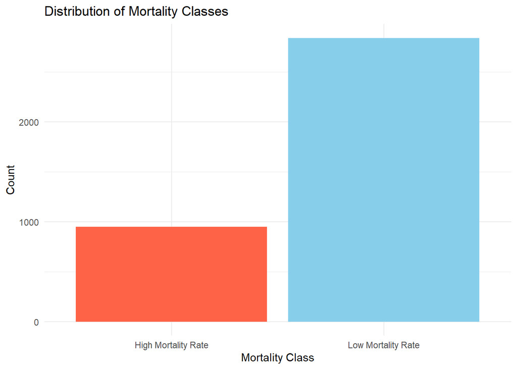

```r
# Visualize the distribution of Mortality Classes
ggplot(merged_df, aes(x = Mortality_Class, fill = Mortality_Class)) +
  geom_bar() +
  labs(
    title = "Distribution of Mortality Classes",
    x = "Mortality Class",
    y = "Count"
  ) +
  theme_minimal() +
  scale_fill_manual(values = c("High Mortality Rate" = "tomato", "Low Mortality Rate" = "skyblue")) +
  theme(legend.position = "none")
```

### **2.2.2. Feature Variables**

We select and prepare relevant feature variables to predict the mortality classes. Proper feature selection enhances model performance, reduces complexity, and mitigates the risk of overfitting. We’ll perform univariate analyses to assess each variable’s predictive power and check for multicollinearity to remove highly correlated variables.

**a. Initial Feature Selection**:

We begin by selecting health-related and socioeconomic variables likely to influence mortality rates. Unique identifiers and non-numeric variables are excluded to maintain the integrity of the models.

```r
# Define the list of health-related variables
health_vars <- c(
  "Outdoor.air.pollution",
  "High.systolic.blood.pressure",
  "Diet.high.in.sodium",
  "Smoking",
  "High.fasting.plasma.glucose",
  "High.body.mass.index",
  "Low.physical.activity",
  "Alochol.use",
  "Diet.low.in.fruits",
  "Diet.low.in.whole.grains"
)

# Socioeconomic variables
socioeconomic_vars <- c(
  "Population",
  "GDP_per_Capita"
)

# Combine all feature variables
feature_vars <- c(health_vars, socioeconomic_vars)

# Create the initial dataset for modeling by selecting the necessary columns
model_df <- merged_df %>%
  select(all_of(feature_vars), Mortality_Class)

# Ensure Mortality_Class is a factor with correct levels
model_df$Mortality_Class <- factor(model_df$Mortality_Class, levels = c("Low Mortality Rate", "High Mortality Rate"))

# Remove any rows with missing values
model_df <- model_df %>% drop_na()

# Inspect the first few rows of the prepared dataset
head(model_df)
```

```
##   Outdoor.air.pollution High.systolic.blood.pressure Diet.high.in.sodium
## 1                  1017                         4280                1561
## 2                  1023                         4384                1593
## 3                   978                         4224                1530
## 4                   934                         4056                1466
## 5                   880                         3855                1385
## 6                   891                         4046                1446
##   Smoking High.fasting.plasma.glucose High.body.mass.index
## 1    2752                         868                 1417
## 2    2809                         902                 1463
## 3    2705                         884                 1415
## 4    2603                         865                 1363
## 5    2453                         837                 1301
## 6    2550                         893                 1371
##   Low.physical.activity Alochol.use Diet.low.in.fruits Diet.low.in.whole.grains
## 1                   117         289                344                      741
## 2                   119         308                355                      764
## 3                   115         314                342                      738
## 4                   111         322                327                      710
## 5                   106         321                307                      673
## 6                   111         351                320                      707
##   Population GDP_per_Capita    Mortality_Class
## 1    3286542       617.2304 Low Mortality Rate
## 2    3266790       336.5870 Low Mortality Rate
## 3    3247039       200.8522 Low Mortality Rate
## 4    3227287       367.2792 Low Mortality Rate
## 5    3207536       586.4161 Low Mortality Rate
## 6    3187784       750.6044 Low Mortality Rate
```

**b. Univariate Analysis**:

We perform univariate logistic regression for each predictor to assess its individual predictive power.

```r
# Initialize a dataframe to store AUC values
univariate_results <- data.frame(Predictor = character(), AUC = numeric(), stringsAsFactors = FALSE)

# List of predictor variables
predictors <- names(model_df)[names(model_df) != "Mortality_Class"]

# Loop through each predictor
for (pred in predictors) {
  formula <- as.formula(paste("Mortality_Class ~", pred))
  model <- glm(formula, data = model_df, family = binomial)
  prob <- predict(model, type = "response")
  roc_curve <- roc(model_df$Mortality_Class, prob, levels = c("Low Mortality Rate", "High Mortality Rate"))
  auc_value <- as.numeric(auc(roc_curve))
  univariate_results <- rbind(univariate_results, data.frame(Predictor = pred, AUC = auc_value))
}

# Sort predictors by AUC
univariate_results <- univariate_results[order(-univariate_results$AUC), ]
print(univariate_results)
```

```
##                       Predictor       AUC
## 12               GDP_per_Capita 0.7770237
## 9            Diet.low.in.fruits 0.6738694
## 8                   Alochol.use 0.6660831
## 3           Diet.high.in.sodium 0.6385481
## 2  High.systolic.blood.pressure 0.6294102
## 4                       Smoking 0.6233263
## 11                   Population 0.5942318
## 5   High.fasting.plasma.glucose 0.5924748
## 1         Outdoor.air.pollution 0.5803651
## 10     Diet.low.in.whole.grains 0.5779696
## 6          High.body.mass.index 0.5470074
## 7         Low.physical.activity 0.5162639
```

**Interpretation of Results:**

**GDP_per_Capita** has the highest AUC (0.7770), indicating it has the best individual predictive power among the variables tested. **Diet.low.in.fruits** and **Alochol.use** have moderate AUC values (around 0.66–0.67), suggesting some predictive ability. The remaining variables have lower AUC values (below 0.65), indicating limited individual predictive power.

Based on the univariate analysis, we’ll use the following variables for the multivariate models:

- **GDP_per_Capita**
- **Diet.low.in.fruits**
- **Alochol.use**
- **Diet.high.in.sodium**
- **High.systolic.blood.pressure**
- **Smoking**

**c. Checking for Multicollinearity**:

We will check for multicollinearity among the selected predictors to identify any highly correlated variables that could negatively affect our models.

**Correlation Matrix Analysis**

We calculated the correlation matrix for the selected variables:

- **GDP_per_Capita**
- **Diet.low.in.fruits**
- **Alochol.use**
- **Diet.high.in.sodium**
- **High.systolic.blood.pressure**
- **Smoking**

```r
# Subset the data to include only the selected predictors
selected_vars <- c(
  "GDP_per_Capita",
  "Diet.low.in.fruits",
  "Alochol.use",
  "Diet.high.in.sodium",
  "High.systolic.blood.pressure",
  "Smoking"
)

# Create a new dataframe with selected predictors
model_df_selected <- model_df %>% select(all_of(selected_vars), Mortality_Class)

# Calculate the correlation matrix
numeric_vars <- model_df_selected %>% select(-Mortality_Class)
corr_matrix <- cor(numeric_vars, use = "complete.obs")

# Display the correlation matrix
print(corr_matrix)
```

```
##                              GDP_per_Capita Diet.low.in.fruits Alochol.use
## GDP_per_Capita                    1.0000000         -0.2122806  -0.1558532
## Diet.low.in.fruits               -0.2122806          1.0000000   0.5635832
## Alochol.use                      -0.1558532          0.5635832   1.0000000
## Diet.high.in.sodium              -0.1929512          0.7117199   0.6377751
## High.systolic.blood.pressure     -0.1286905          0.8462182   0.6947478
## Smoking                          -0.0175408          0.7248826   0.5776375
##                              Diet.high.in.sodium High.systolic.blood.pressure
## GDP_per_Capita                        -0.1929512                   -0.1286905
## Diet.low.in.fruits                     0.7117199                    0.8462182
## Alochol.use                            0.6377751                    0.6947478
## Diet.high.in.sodium                    1.0000000                    0.7848835
## High.systolic.blood.pressure           0.7848835                    1.0000000
## Smoking                                0.7239765                    0.8819455
##                                 Smoking
## GDP_per_Capita               -0.0175408
## Diet.low.in.fruits            0.7248826
## Alochol.use                   0.5776375
## Diet.high.in.sodium           0.7239765
## High.systolic.blood.pressure  0.8819455
## Smoking                       1.0000000
```

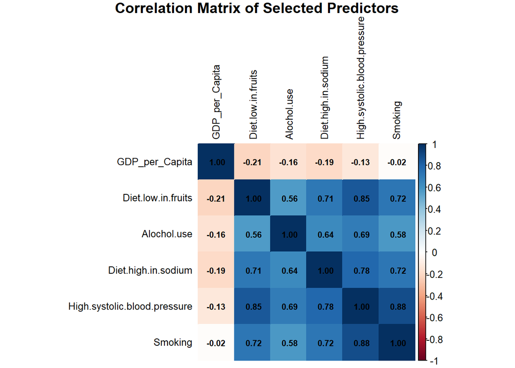

Correlation Matrix of Selected Predictors

| Predictor | GDP_per_Capita | Diet.low.in.fruits | Alochol.use | Diet.high.in.sodium | High.systolic.blood.pressure | Smoking |
| --- | --- | --- | --- | --- | --- | --- |
| **GDP_per_Capita** | 1.00 | -0.21 | -0.16 | -0.19 | -0.13 | -0.02 |
| **Diet.low.in.fruits** | -0.21 | 1.00 | 0.56 | 0.71 | 0.85 | 0.72 |
| **Alochol.use** | -0.16 | 0.56 | 1.00 | 0.64 | 0.69 | 0.58 |
| **Diet.high.in.sodium** | -0.19 | 0.71 | 0.64 | 1.00 | 0.78 | 0.72 |
| **High.systolic.blood.pressure** | -0.13 | 0.85 | 0.69 | 0.78 | 1.00 | 0.88 |
| **Smoking** | -0.02 | 0.72 | 0.58 | 0.72 | 0.88 | 1.00 |

```r
# Plot the correlation matrix
corrplot(corr_matrix, method = "color", addCoef.col = "black", number.cex = 0.7,
         tl.cex = 0.8, tl.col = "black", title = "Correlation Matrix of Selected Predictors",
         mar = c(0, 0, 1, 0))
```

**Interpretation of Results:**

High.systolic.blood.pressure is highly correlated with:

- **Smoking** (0.88)
- **Diet.low.in.fruits** (0.85)
- **Diet.high.in.sodium** (0.78)

Smoking is also highly correlated with:

- **Diet.low.in.fruits** (0.72)
- **Diet.high.in.sodium** (0.72)

Due to high multicollinearity, we decided to remove **High.systolic.blood.pressure** and **Smoking** from the predictor set. We retained **Diet.low.in.fruits**, **Alochol.use**, and **Diet.high.in.sodium** as they have acceptable correlations after variable removal.

The final set of predictors is:

- **GDP_per_Capita**
- **Diet.low.in.fruits**
- **Alochol.use**
- **Diet.high.in.sodium**

After removing the highly correlated variables, we recalculated the correlation matrix to confirm that multicollinearity concerns were addressed.

```r
# Final list of predictors
final_vars <- c(
  "GDP_per_Capita",
  "Diet.low.in.fruits",
  "Alochol.use",
  "Diet.high.in.sodium"
)

# Create the final modeling dataset
model_df_final <- model_df %>% select(all_of(final_vars), Mortality_Class)

# Calculate the correlation matrix
numeric_vars_final <- model_df_final %>% select(-Mortality_Class)
corr_matrix_final <- cor(numeric_vars_final, use = "complete.obs")

# Display the correlation matrix
print(corr_matrix_final)
```

```
##                     GDP_per_Capita Diet.low.in.fruits Alochol.use
## GDP_per_Capita           1.0000000         -0.2122806  -0.1558532
## Diet.low.in.fruits      -0.2122806          1.0000000   0.5635832
## Alochol.use             -0.1558532          0.5635832   1.0000000
## Diet.high.in.sodium     -0.1929512          0.7117199   0.6377751
##                     Diet.high.in.sodium
## GDP_per_Capita               -0.1929512
## Diet.low.in.fruits            0.7117199
## Alochol.use                   0.6377751
## Diet.high.in.sodium           1.0000000
```

**Table: Updated Correlation Matrix**

| Predictor | GDP_per_Capita | Diet.low.in.fruits | Alochol.use | Diet.high.in.sodium |
| --- | --- | --- | --- | --- |
| **GDP_per_Capita** | 1.00 | -0.21 | -0.16 | -0.19 |
| **Diet.low.in.fruits** | -0.21 | 1.00 | 0.56 | 0.71 |
| **Alochol.use** | -0.16 | 0.56 | 1.00 | 0.64 |
| **Diet.high.in.sodium** | -0.19 | 0.71 | 0.64 | 1.00 |

**Interpretation of Results:**

The highest correlation is between **Diet.low.in.fruits** and **Diet.high.in.sodium** (0.71), which is below the threshold of 0.8. Other correlations are moderate to low, indicating that multicollinearity is not a significant concern with these variables.

**Variance Inflation Factor (VIF) Analysis**

We calculated the VIF values for the updated predictors to further assess multicollinearity.

```r
# Fit a logistic regression model with the final predictors
vif_model_final <- glm(Mortality_Class ~ ., data = model_df_final, family = binomial)

# Calculate VIF values
vif_values_final <- vif(vif_model_final)
print(vif_values_final)
```

```
##      GDP_per_Capita  Diet.low.in.fruits         Alochol.use Diet.high.in.sodium
##            1.051292            2.006070            1.644573            2.304858
```

**Table: VIF Values of Final Predictors**

| Predictor | VIF |
| --- | --- |
| GDP_per_Capita | 1.05 |
| Diet.low.in.fruits | 2.01 |
| Alochol.use | 1.64 |
| Diet.high.in.sodium | 2.30 |

**Interpretation of Results:**

All VIF values are below 5, suggesting that multicollinearity is within acceptable limits. This confirms that our final set of predictors is suitable for modeling without multicollinearity issues.

By analyzing the correlation matrix and VIF values, we refined our predictor set to include variables that contribute uniquely to the model:

- **GDP_per_Capita**
- **Diet.low.in.fruits**
- **Alochol.use**
- **Diet.high.in.sodium**

This refined set of predictors enhances the reliability and interpretability of our models, allowing us to proceed confidently to the modeling phase.

**d. Final Feature Variables**:

Based on the univariate analysis and multicollinearity checks, we refined our feature variables to enhance model performance and interpretability:

- **GDP_per_Capita**
- **Diet.low.in.fruits**
- **Alochol.use**
- **Diet.high.in.sodium**

```r
# Final list of predictors including the response variable
final_vars <- c(
  "GDP_per_Capita",
  "Diet.low.in.fruits",
  "Alochol.use",
  "Diet.high.in.sodium",
  "Mortality_Class"  # This is our response variable
)

# Update the modeling dataset
model_df <- model_df %>% select(all_of(final_vars))

# Ensure Mortality_Class is a factor with correct levels
model_df$Mortality_Class <- factor(model_df$Mortality_Class, levels = c("Low Mortality Rate", "High Mortality Rate"))

# Verify that there are no missing values
sum(is.na(model_df))  # Should be 0 if data is clean
```

```
## [1] 0
```

```r
# Inspect the structure of the final dataset
str(model_df)
```

```
## 'data.frame':    3785 obs. of  5 variables:
##  $ GDP_per_Capita     : num  617 337 201 367 586 ...
##  $ Diet.low.in.fruits : int  344 355 342 327 307 320 331 335 334 330 ...
##  $ Alochol.use        : int  289 308 314 322 321 351 388 437 480 497 ...
##  $ Diet.high.in.sodium: int  1561 1593 1530 1466 1385 1446 1510 1546 1566 1582 ...
##  $ Mortality_Class    : Factor w/ 2 levels "Low Mortality Rate",..: 1 1 1 1 1 1 1 1 1 1 ...
```

## **2.3. Null Model**

A **Null Model** serves as a baseline to evaluate the performance of more complex classification models. In this context, the null model predicts the most frequent class for all observations, disregarding any input features. This provides a reference point to determine whether the predictive models offer a meaningful improvement over random or simplistic guessing.

Given the distribution of our binary classes:

- **High Mortality Rate**: 947 observations
- **Low Mortality Rate**: 2,838 observations

The null model will predict **“Low Mortality Rate”** for every country-year observation since it is the majority class.

```r
# Calculate the distribution of the binary classes
class_distribution <- table(model_df$Mortality_Class)
print(class_distribution)
```

```
##
##  Low Mortality Rate High Mortality Rate
##                2838                 947
```

```r
# Determine the most frequent class
most_frequent_class <- names(which.max(class_distribution))
print(paste("Most Frequent Class:", most_frequent_class))
```

```
## [1] "Most Frequent Class: Low Mortality Rate"
```

```r
# Create predictions based on the null model
null_predictions <- rep(most_frequent_class, nrow(model_df))

# Calculate Accuracy of the Null Model
null_accuracy <- mean(null_predictions == model_df$Mortality_Class)
print(paste("Null Model Accuracy:", round(null_accuracy * 100, 2), "%"))
```

```
## [1] "Null Model Accuracy: 74.98 %"
```

```r
# Generate a Confusion Matrix for the Null Model
confusion_null <- confusionMatrix(
  factor(null_predictions, levels = levels(model_df$Mortality_Class)),
  model_df$Mortality_Class
)

print(confusion_null)
```

```
## Confusion Matrix and Statistics
##
##                      Reference
## Prediction            Low Mortality Rate High Mortality Rate
##   Low Mortality Rate                2838                 947
##   High Mortality Rate                  0                   0
##
##                Accuracy : 0.7498
##                  95% CI : (0.7357, 0.7635)
##     No Information Rate : 0.7498
##     P-Value [Acc > NIR] : 0.5087
##
##                   Kappa : 0
##
##  Mcnemar's Test P-Value : <2e-16
##
##             Sensitivity : 1.0000
##             Specificity : 0.0000
##          Pos Pred Value : 0.7498
##          Neg Pred Value :    NaN
##              Prevalence : 0.7498
##          Detection Rate : 0.7498
##    Detection Prevalence : 1.0000
##       Balanced Accuracy : 0.5000
##
##        'Positive' Class : Low Mortality Rate
##
```

**Interpretation of Results:**

- **Accuracy:** The null model achieves an accuracy of **74.98%**, which corresponds to the proportion of the majority class (**Low Mortality Rate**). This means that without considering any features, simply predicting the most frequent class yields an accuracy of approximately **74.98%**.
- **Confusion Matrix Insights:**
  - **True Positives** (High Mortality Rate predicted as High): 0
  - **False Negatives** (High Mortality Rate predicted as Low): 947
  - **True Negatives** (Low Mortality Rate predicted as Low): 2,838
  - **False Positives** (Low Mortality Rate predicted as High): 0
- **Performance Metrics:**
  - **Sensitivity (Recall) for High Mortality Rate:** 0% (no high mortality rates are correctly predicted)
  - **Specificity for Low Mortality Rate:** 100% (all low mortality rates are correctly predicted)
  - **Kappa:** 0, indicating no agreement beyond chance.
  - **Balanced Accuracy:** 50%, reflecting equal weighting of sensitivity and specificity.

The null model provides a benchmark against which we can assess the effectiveness of our classification models. Any predictive model should aim to outperform this baseline, demonstrating its ability to capture meaningful patterns and relationships within the data. By comparing our models’ performance metrics to those of the null model, we can quantify the added value of incorporating health, socioeconomic, and environmental factors into our predictions.

## **2.4. Splitting the Data**

To evaluate the performance of our classification models effectively, it is essential to divide the dataset into separate **training** and **testing** subsets. This separation allows us to train the models on one portion of the data and assess their generalization capabilities on unseen data.

- **Training Set:** Used to build and tune the classification models.
- **Testing Set:** Used to evaluate the models’ performance on new, unseen data, ensuring that the models do not overfit and can generalize well.

An **80/20 split** is commonly used, allocating 80% of the data for training and 20% for testing. This ratio provides a substantial amount of data for model training while retaining enough observations to reliably assess model performance.

```r
# Set seed for reproducibility
set.seed(123)

# Create a partition index for 80% training data
train_index <- createDataPartition(model_df$Mortality_Class, p = 0.8, list = FALSE)

# Split the data into training and testing sets
train_data <- model_df[train_index, ]
test_data  <- model_df[-train_index, ]

# Verify the distribution of classes in training and testing sets
train_distribution <- table(train_data$Mortality_Class)
test_distribution  <- table(test_data$Mortality_Class)

print("Training Set Class Distribution:")
```

```
## [1] "Training Set Class Distribution:"
```

```r
print(train_distribution)
```

```
##
## High Mortality Rate  Low Mortality Rate
##                 758                2271
```

```r
print("Testing Set Class Distribution:")
```

```
## [1] "Testing Set Class Distribution:"
```

```r
print(test_distribution)
```

```
##
## High Mortality Rate  Low Mortality Rate
##                 189                 567
```

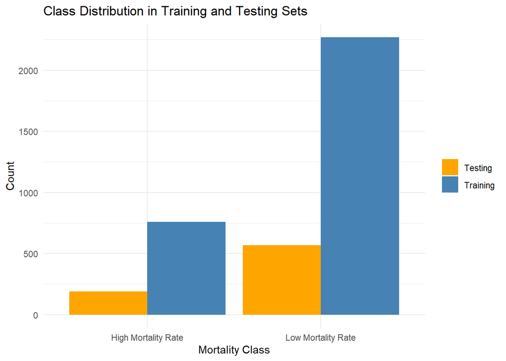

```r
# Visualize the class distribution in training and testing sets

# Combine distributions into a single dataframe for plotting
distribution_df <- data.frame(
  Class = rep(names(train_distribution), 2),
  Count = c(train_distribution, test_distribution),
  Set = rep(c("Training", "Testing"), each = length(train_distribution))
)

ggplot(distribution_df, aes(x = Class, y = Count, fill = Set)) +
  geom_bar(stat = "identity", position = "dodge") +
  labs(
    title = "Class Distribution in Training and Testing Sets",
    x = "Mortality Class",
    y = "Count"
  ) +
  theme_minimal() +
  scale_fill_manual(values = c("Training" = "steelblue", "Testing" = "orange")) +
  theme(legend.title = element_blank())
```

The class distribution in both the training and testing sets mirrors the overall distribution of the dataset, maintaining approximately 25% of observations as High Mortality Rate and 75% as Low Mortality Rate. This stratified sampling ensures that both subsets are representative of the entire dataset, facilitating reliable model training and evaluation.

## **2.5. Classification Models**

We develop and evaluate two classification models to predict the **Mortality Class** (**High Mortality Rate** vs. **Low Mortality Rate**) for each country-year observation. The chosen models are:

1. **Decision Tree Classifier**
2. **Logistic Regression Classifier**

These models are selected for their interpretability and effectiveness in binary classification tasks.

### **2.5.1. Decision Tree Classifier**

Decision Trees are intuitive models that split the data based on feature values to create decision rules leading to the target class. They are easy to visualize and interpret, making them suitable for understanding the factors influencing mortality rates.

[figure not shown]

```r
# Ensure that Mortality_Class is a factor in both train and test datasets
train_data$Mortality_Class <- factor(train_data$Mortality_Class, levels = c("Low Mortality Rate", "High Mortality Rate"))
test_data$Mortality_Class <- factor(test_data$Mortality_Class, levels = c("Low Mortality Rate", "High Mortality Rate"))

# Train the Decision Tree model
tree_model <- rpart(
  Mortality_Class ~ .,
  data = train_data,
  method = "class",
  control = rpart.control(cp = 0.01)  # cp is the complexity parameter
)

# Visualize the Decision Tree
rpart.plot(tree_model, type = 2, extra = 104, fallen.leaves = TRUE, main = "Decision Tree for Mortality Classification", cex = 0.3)
```

```r
# Predict on the testing set
tree_predictions <- predict(tree_model, newdata = test_data, type = "class")

# Convert predictions to factor with the same levels as Mortality_Class
tree_predictions <- factor(tree_predictions, levels = levels(test_data$Mortality_Class))

# Generate Confusion Matrix
confusion_tree <- confusionMatrix(tree_predictions, test_data$Mortality_Class)
print(confusion_tree)
```

```
## Confusion Matrix and Statistics
##
##                      Reference
## Prediction            Low Mortality Rate High Mortality Rate
##   Low Mortality Rate                 551                  33
##   High Mortality Rate                 16                 156
##
##                Accuracy : 0.9352
##                  95% CI : (0.9152, 0.9517)
##     No Information Rate : 0.75
##     P-Value [Acc > NIR] : < 2e-16
##
##                   Kappa : 0.8218
##
##  Mcnemar's Test P-Value : 0.02227
##
##             Sensitivity : 0.9718
##             Specificity : 0.8254
##          Pos Pred Value : 0.9435
##          Neg Pred Value : 0.9070
##              Prevalence : 0.7500
##          Detection Rate : 0.7288
##    Detection Prevalence : 0.7725
##       Balanced Accuracy : 0.8986
##
##        'Positive' Class : Low Mortality Rate
##
```

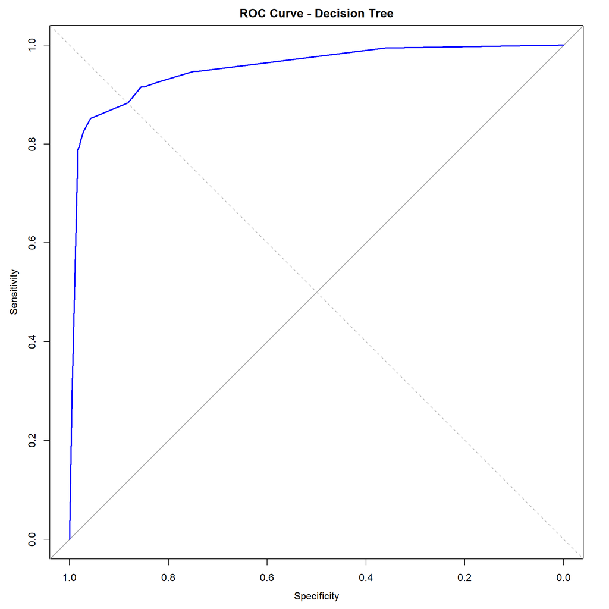

```r
# Calculate ROC and AUC for Decision Tree
tree_prob <- predict(tree_model, newdata = test_data, type = "prob")[,2]
roc_tree <- roc(response = test_data$Mortality_Class,
                predictor = tree_prob,
                levels = c("Low Mortality Rate", "High Mortality Rate"))

# Plot ROC Curve
plot(roc_tree, col = "blue", main = "ROC Curve - Decision Tree")
abline(a=0, b=1, lty=2, col="gray")
```

```r
# Display AUC
auc_tree <- auc(roc_tree)
print(paste("Decision Tree AUC:", round(auc_tree, 4)))
```

```
## [1] "Decision Tree AUC: 0.9534"
```

**Interpretation of Results:**

**Confusion Matrix Insights:**

**Overall Assessment:**

The decision tree model performs well in classifying countries into low and high mortality rate categories. It shows a strong balance between sensitivity and specificity, and the high AUC value indicates reliable discriminative power. The model’s performance is significantly better than the null model, highlighting its effectiveness.

### **2.5.2. Logistic Regression Classifier**

Logistic Regression is a probabilistic model suitable for binary classification tasks. It estimates the probability that a given input point belongs to a particular class, making it effective for understanding the relationship between features and the target variable.

```r
# Ensure Mortality_Class is a factor with correct levels
train_data$Mortality_Class <- factor(train_data$Mortality_Class, levels = c("Low Mortality Rate", "High Mortality Rate"))
test_data$Mortality_Class <- factor(test_data$Mortality_Class, levels = c("Low Mortality Rate", "High Mortality Rate"))

# Train the Logistic Regression model
logistic_model <- glm(
  Mortality_Class ~ .,
  data = train_data,
  family = binomial
)

# Predict probabilities on the testing set
logistic_prob <- predict(logistic_model, newdata = test_data, type = "response")

# Convert probabilities to class labels using 0.5 as threshold
logistic_predictions <- ifelse(logistic_prob >= 0.5, "High Mortality Rate", "Low Mortality Rate")
logistic_predictions <- factor(logistic_predictions, levels = levels(test_data$Mortality_Class))

# Generate Confusion Matrix
confusion_logistic <- confusionMatrix(logistic_predictions, test_data$Mortality_Class)
print(confusion_logistic)
```

```
## Confusion Matrix and Statistics
##
##                      Reference
## Prediction            Low Mortality Rate High Mortality Rate
##   Low Mortality Rate                 555                  25
##   High Mortality Rate                 12                 164
##
##                Accuracy : 0.9511
##                  95% CI : (0.9332, 0.9653)
##     No Information Rate : 0.75
##     P-Value [Acc > NIR] : < 2e-16
##
##                   Kappa : 0.8664
##
##  Mcnemar's Test P-Value : 0.04852
##
##             Sensitivity : 0.9788
##             Specificity : 0.8677
##          Pos Pred Value : 0.9569
##          Neg Pred Value : 0.9318
##              Prevalence : 0.7500
##          Detection Rate : 0.7341
##    Detection Prevalence : 0.7672
##       Balanced Accuracy : 0.9233
##
##        'Positive' Class : Low Mortality Rate
##
```

[figure not shown]

```r
# Calculate ROC and AUC
roc_logistic <- roc(response = test_data$Mortality_Class, predictor = logistic_prob, levels = c("Low Mortality Rate", "High Mortality Rate"))

# Plot ROC Curve
plot(roc_logistic, col = "red", main = "ROC Curve - Logistic Regression")
abline(a=0, b=1, lty=2, col="gray")
```

```r
# Display AUC
auc_logistic <- auc(roc_logistic)
print(paste("Logistic Regression AUC:", round(auc_logistic, 4)))
```

```
## [1] "Logistic Regression AUC: 0.9233"
```

**Interpretation of Results:**

**Confusion Matrix Insights:**

**Overall Assessment:**

## **2.6. Model Evaluation**

**Decision Tree Classifier Performance:**

**Logistic Regression Classifier Performance:**

**Comparison and Discussion:**

**Impact of Feature Selection:**

**Overall Assessment:**